# Quantile Regressions in R: A Quick Tutorial

Jorge A. Chan-Lau

International Monetary Fund and Risk Management Institute, National University of Singapore

Workshop at Superintendencia de Banca, Seguros y AFPs, Lima, Peru on June 5-8, 2017

This tutorial provides a quick introduction to the estimation of quantile regression models using the `R` package `quantreg` developed by Roger Koenker. To illustrate the use of the methods contained in the package, we will examine how macroeconomic and financial variables affect the behavior of the NPL rate of consumer loans in the banking sector. The reader should complement the tutorial with [Koenker (2017), Quantile Regression in R: A Vignette](https://cran.r-project.org/web/packages/quantreg/vignettes/rq.pdf). To become familiar with `R`, the freely available primer by G. Jay Kerns, [Introduction to Probabiity and Statistics using R](http://ipsur.org/index.html) is quite useful. [UCLA’s Institute for Digital Research and Education `R` online tutorials](http://stats.idre.ucla.edu/r/) are also a great resource.

# Getting started

## Setting up the working directory

Start RStudio. In the IDE, go to the console window. There, change the woking directory to the one containing the data files using the command `setwd()`. The argument for the command should be the name of the desired working directory.

```r
setwd("D:/Work/Lima Workshop")
```

To confirm the working directory is the desired one, type `getwd()` and execute the command pressing the `Enter` key.

```r
getwd()
```

```
## [1] "D:/Work/Lima Workshop"
```

```r
rm(list=ls())
```

## Reading data files

To read the data files, we will use the function `read.csv`, included in the base package `utils`. Note that the function requires passing the name of the data file, specify whether there is a header row, and what character separates individual data entries:

```r
fileName = "dataLimaWorkshop.csv"
theData  = read.csv(fileName, header = TRUE, sep = ",")
```

Check your RStudio IDE. The Environment tab should display the two new objects creatd, `fileName` and `theData`. The last object is a `R` data frame, and it is listed separately from other objects. The source window, to the left, displays the data frame `theData`. For relatively small data sets, it is possible to check the data in this window.

[figure not shown]

## Installing and loading packages

There are numerous mathematical and statistical methods in `R` available through external packages (or libraries) stored in the `CRAN` repository. The tutorial uses several packages: `quantreg` to estimate quantile regression models; `lubridate` and `dplyr` to manipulate data; and `ggplot2` to produce charts.

Installing a package requires downloading it first. When there is access to the Internet, the following command checks whether the package is installed, and downloads it if not:

```r
if(!require(quantreg)){install.packages("quantreg")}
if(!require(dplyr)){install.packages("dplyr")}
```

```r
if(!require(ggplot2)){install.packages("ggplot2")}
if(!require(lubridate)){install.packages("lubridate")}
```

To make the libraries accessible the `R` programs, run the `library()` command:

```r
library(quantreg)
library(dplyr)
library(ggplot2)
library(lubridate)
```

Since we will use plots against dates, it is necessary to format the `Date` variable to a format the plotting commands can recognize:

```r
theData$Date = mdy(theData$Date)
```

# Case Study: Mexico’s consumer loan NPL

## Setting up the data frame

The example uses only a subset of variables from our data set:

- IGAE, which is the Indice General de Actividad Economica
- USDMXN, the exchange rate of the Mexican peso vis-a-vis the US dollar
- RateConsumer, the average rate for consumer loans in the Mexican banking system

The quantile regressions use as covariates, or explanatory variables, the yoy growth rate of the IGAE, the yoy depreciation of the peso, and the rate of consumer loans. The commands below construct the first two variables.

First, attach the data frame `theData` to have access to the variables it contains:

```r
attach(theData)
```

Calculate the yoy growth rate of IGAE and store it in the data frame with the name `IGAEgrowth`:

```r
# anual percentage change, index of general economic activity
thelag = 12
IGAEgrowth = IGAE/lag(IGAE, n = thelag)*100 - 100
IGAEgrowth = IGAEgrowth
theData$IGAEgrowth = IGAEgrowth
```

Similarly, the exchange rate depreciation, `FXdepr`, is constructed as:

```r
theData$FXdepr = USDMXN/lag(USDMXN,n=thelag)*100- 100
```

Because the NPL rate is right skewed, with fat tails, we apply a log-transformation to the NPL rate, which we save in the data frame as `logNPLCons`, as follows:

```r
theData$logNPLCons = log(1+NPLConsumer/100)
```

There are several `NaN`s in the data. To remove them, we extract a data frame with only valid observations, `completeData`, from the original data frame `theData`. In addition, we remove the first three years of data, or 36 months, since some argue there have been structural changes in the banking system. Finally, we detach the original data frame since we will no longer use it:

```r
# Keep only valid observations
completeData = theData[complete.cases(theData),]
# Remove the first three years of data
completeData = completeData[-(1:36),]
detach(theData)
```

## A graphical examination of the relationship of NPL rate to the covariates

Let’s examine informally a number of scatter plots of the log-transformed NPL against our choice of covariates. First, against the yoy growth rate of economic activity:

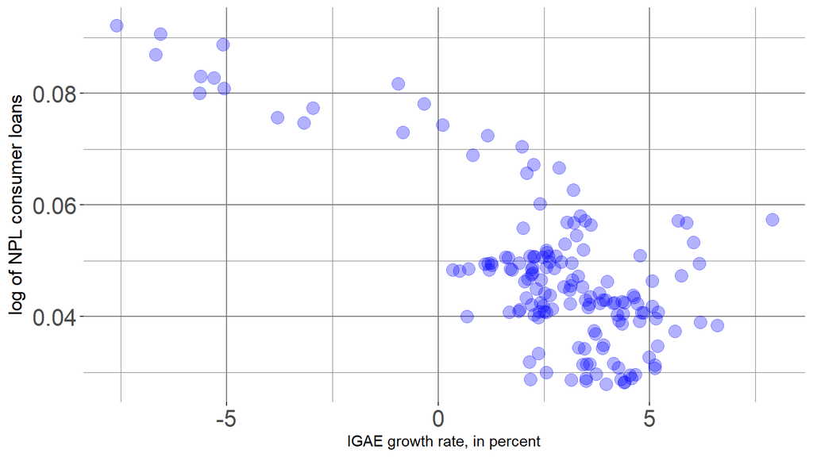

```r
ggplot(completeData, aes(x=IGAEgrowth, y=logNPLCons)) +  # creates ggplot chart
  geom_point(col="blue", size=4, alpha=0.3) +            # geom_point plots data points
  xlab("IGAE growth rate, in percent") +                 # x-axis label
  ylab("log of NPL consumer loans") +                    # y-axis label
  # we format chart with theme
  theme(plot.background = element_rect(fill="transparent", colour=NA),
        panel.grid.major = element_line(colour="gray50"),
        panel.grid.minor = element_line(colour="gray50"),
        panel.border = element_blank(),
        panel.background = element_blank(),
        axis.text = element_text(size=rel(1.5)),
        axis.title.y = element_text(size= rel(1.2)))
```

As expected, the scatter plot clearly indicates a negative relationship between the pace of economic activity and the NPL rate of consumer loans. Now, let’s look at the possible impact of the depreciation of the exchange rate:

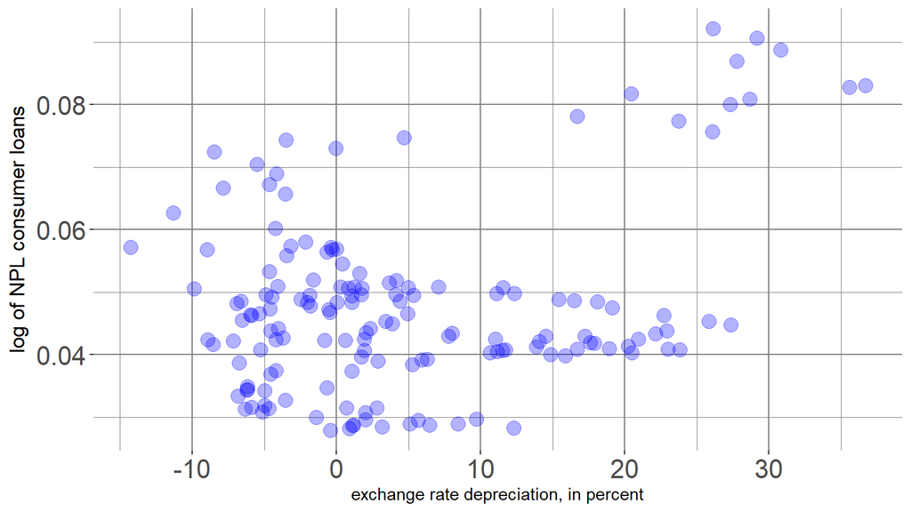

```r
ggplot(completeData, aes(x=FXdepr, y=logNPLCons)) +
  geom_point(col="blue", size=4, alpha=0.3) +
  xlab("exchange rate depreciation, in percent") +
  ylab("log of NPL consumer loans") +
  theme(plot.background = element_rect(fill="transparent", colour=NA),
        panel.grid.major = element_line(colour="gray50"),
        panel.grid.minor = element_line(colour="gray50"),
        #panel.border = element_rect(linetype = "solid", colour="gray50", fill = NA),
        panel.border = element_blank(),
        panel.background = element_blank(),
        axis.text = element_text(size=rel(1.5)),
        axis.title.y = element_text(size= rel(1.2)))
```

The picture here is not as clear. The relationship appears positive when considering all points. But once we omit the points in the upper right section of the chart, an exchange rate depreciation appears to reduce the NPL rate of consumer loans. Finally, we turn to the rate of consumer loans. We expect higher rates makes the realization of NPLs more likely. The chart below provides some support for this assertion:

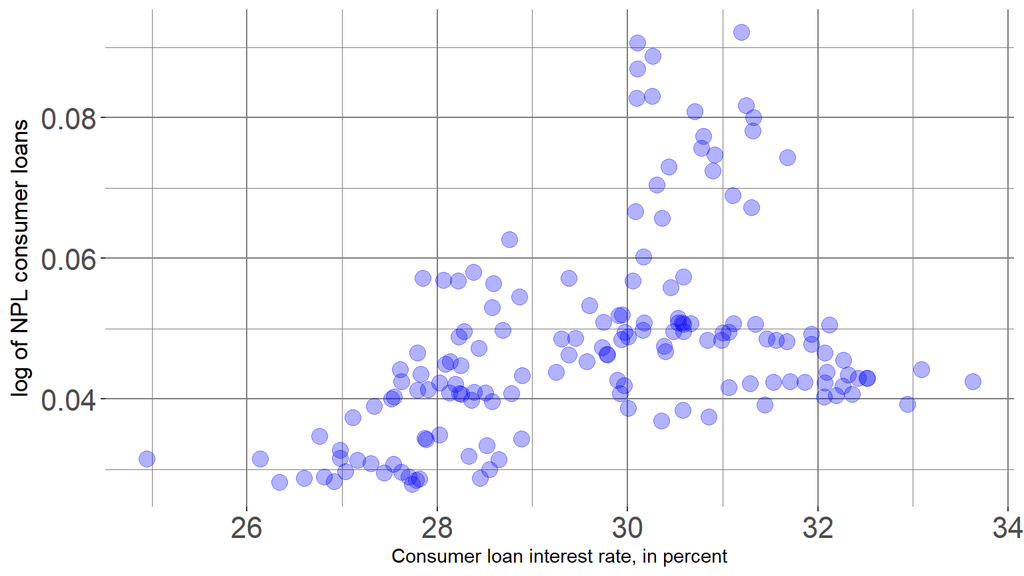

```r
ggplot(completeData, aes(x=RateConsumer, y=logNPLCons)) +
  geom_point(col="blue", size=4, alpha=0.3) +
  xlab("Consumer loan interest rate, in percent") +
  ylab("log of NPL consumer loans") +
  theme(plot.background = element_rect(fill="transparent", colour=NA),
        panel.grid.major = element_line(colour="gray50"),
        panel.grid.minor = element_line(colour="gray50"),
        #panel.border = element_rect(linetype = "solid", colour="gray50", fill = NA),
        panel.border = element_blank(),
        panel.background = element_blank(),
        axis.text = element_text(size=rel(1.5)),
        axis.title.y = element_text(size= rel(1.2)))
```

# Fitting the QR model

Let’s fit the QR models now. As a first step, load the libraries `quantreg` and `dplyr`, and transform the covariates to plain numbers rather than percentages:

```r
library(quantreg,dplyr)
attach(completeData)
completeData$IGAEgrowth = completeData$IGAEgrowth/100
completeData$FXdepr = completeData$FXdepr/100
completeData$RateConsumer = completeData$RateConsumer/100
```

Estimating the model requires just a few lines of code. First, define the quantiles of interest in the numeric array `taus`:

```r
taus = c(0.05, 0.10, 0.25, 0.50, 0.75, 0.90, 0.95)
```

The object `formula` defines the model specification:

```r
formula = logNPLCons ~IGAEgrowth + FXdepr + RateConsumer
```

We estimate the linear regression model first, which we will compare against the quantile regressions later. The OLs estimation uses the command `lm()`, and the command `summary()` provides a bird’s eyes view of the results:

```r
NPLlm = lm(formula, data=completeData)
summary(NPLlm)
```

```
##
## Call:
## lm(formula = formula, data = completeData)
##
## Residuals:
##       Min        1Q    Median        3Q       Max
## -0.018808 -0.006127 -0.001337  0.004829  0.028278
##
## Coefficients:
##               Estimate Std. Error t value Pr(>|t|)
## (Intercept)  -0.001262   0.012877  -0.098    0.922
## IGAEgrowth   -0.407816   0.033806 -12.063  < 2e-16 ***
## FXdepr       -0.011982   0.007831  -1.530    0.128
## RateConsumer  0.203401   0.042217   4.818 3.48e-06 ***
## ---
## Signif. codes:  0 '***' 0.001 '**' 0.01 '*' 0.05 '.' 0.1 ' ' 1
##
## Residual standard error: 0.008762 on 152 degrees of freedom
## Multiple R-squared:  0.6326, Adjusted R-squared:  0.6254
## F-statistic: 87.25 on 3 and 152 DF,  p-value: < 2.2e-16
```

To estimate the QR, we use the function `rq` from the `quantreg` package:

```r
NPLQR = rq(formula, tau = taus, completeData, method="br")
```

Note that we use the solution method `br`, or Barrodale and Roberts algorithm, which Koenker recommends for small and medium-sized data. Use again the `summary()` function to explore the results for each of the quantiles. The lower and upper bounds of the coefficients are obtained using the rank inversion method.

```r
summary(NPLQR)
```

```
##
## Call: rq(formula = formula, tau = taus, data = completeData, method = "br")
##
## tau: [1] 0.05
##
## Coefficients:
##              coefficients lower bd upper bd
## (Intercept)  -0.03486     -0.04467 -0.02248
## IGAEgrowth   -0.39061     -0.40343 -0.01175
## FXdepr        0.02770      0.01434  0.03192
## RateConsumer  0.27217      0.23507  0.30445
##
## Call: rq(formula = formula, tau = taus, data = completeData, method = "br")
##
## tau: [1] 0.1
##
## Coefficients:
##              coefficients lower bd upper bd
## (Intercept)  -0.02482     -0.03083 -0.01656
## IGAEgrowth   -0.35728     -0.40039 -0.26225
## FXdepr        0.02204      0.01605  0.02746
## RateConsumer  0.24144      0.21768  0.27309
##
## Call: rq(formula = formula, tau = taus, data = completeData, method = "br")
##
## tau: [1] 0.25
##
## Coefficients:
##              coefficients lower bd upper bd
## (Intercept)  -0.00821     -0.01264 -0.00366
## IGAEgrowth   -0.40360     -0.45456 -0.32732
## FXdepr        0.00708      0.00259  0.01486
## RateConsumer  0.20273      0.18849  0.21224
##
## Call: rq(formula = formula, tau = taus, data = completeData, method = "br")
##
## tau: [1] 0.5
##
## Coefficients:
##              coefficients lower bd upper bd
```

[output cut: 22 more lines]

```
## (Intercept)  -0.00511     -0.10156  0.07174
## IGAEgrowth   -0.43123     -0.55560 -0.39785
## FXdepr       -0.04517     -0.06151 -0.03091
## RateConsumer  0.26780      0.00224  0.58735
##
## Call: rq(formula = formula, tau = taus, data = completeData, method = "br")
##
## tau: [1] 0.95
##
## Coefficients:
##              coefficients lower bd upper bd
## (Intercept)  -0.05002     -0.12073  0.12859
## IGAEgrowth   -0.39379     -0.45925 -0.25117
## FXdepr       -0.03509     -0.04715  0.00275
## RateConsumer  0.42374     -0.17041  0.66238
```

When we want to examine the results for a single quantile, suppose quantile $\tau=0.75$, which is the 5-th element in the `taus` vector grouping the quantiles for which we estimated the QRs:

```r
summary(NPLQR)[[5]]
```

```
##
## Call: rq(formula = formula, tau = taus, data = completeData, method = "br")
##
## tau: [1] 0.75
##
## Coefficients:
##              coefficients lower bd upper bd
## (Intercept)   0.00626     -0.03257  0.06287
## IGAEgrowth   -0.49438     -0.55764 -0.42662
## FXdepr       -0.03889     -0.05561 -0.02190
## RateConsumer  0.20930      0.01963  0.35008
```

Now, if we forgot the ordering of the `taus` array, and we want to see the results of $\tau = 0.25$, use the `which` command as done below:

```r
summary(NPLQR)[[which(taus==0.25)]]
```

```
##
## Call: rq(formula = formula, tau = taus, data = completeData, method = "br")
##
## tau: [1] 0.25
##
## Coefficients:
##              coefficients lower bd upper bd
## (Intercept)  -0.00821     -0.01264 -0.00366
## IGAEgrowth   -0.40360     -0.45456 -0.32732
## FXdepr        0.00708      0.00259  0.01486
## RateConsumer  0.20273      0.18849  0.21224
```

# Compare the fitted model against the data

Find the fitted values of the linear regression model and the QR models using the method `fitted.values()` applied to each one of the regression objects, `NPLlm` and `NPLQR`. The fitted values are stored in a data frame, `the.data`, which we use later on to produce the figure.

```r
the.data = data.frame(cbind(fitted.values(NPLlm),fitted.values(NPLQR)))
```

The dimensions of `fitted.values(NPLQR)` are 156 by 7, each column corresponding to one of the estimated QR models - remember our array of quantile values, `taus`, has a dimension of 7:

```r
dim(fitted.values(NPLQR))
```

```
## [1] 156   7
```

Since we are plotting historical time series, add the `Date` element from the data frame `completeData` to `the.data`, together with the original time series, `logNPLCons`:

```r
the.data$Date = completeData$Date
the.data$NPL = completeData$logNPLCons
```

Now we are ready to plot the results:

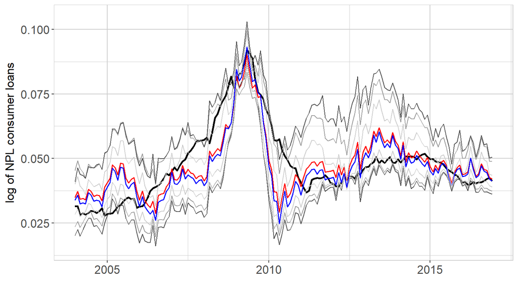

```r
ggplot(the.data, aes(x=Date)) +
  # add the observed NPLs in black, solid line
  geom_line(aes(y=the.data$NPL), color="black", size = 1.0, linetype ="solid")  +
  # add the linear regression estimates
  geom_line(aes(y=the.data[,1]), color = "red", size = 0.6, linetype ="solid") +
  # start adding the quantile estimates in gray, from darker to lighter
  geom_line(aes(y=the.data[,2]), color = "gray30") +
  geom_line(aes(y=the.data[,3]), color = "gray60") +
  geom_line(aes(y=the.data[,4]), color = "gray80") +
  # add the median quantile regression in blue
  geom_line(aes(y=the.data[,5]), color = "blue", size = 0.6, linetype="solid") +
  # finalize by adding the remaining quantile estimates
  geom_line(aes(y=the.data[,6]), color = "gray80") +
  geom_line(aes(y=the.data[,7]), color = "gray60") +
  geom_line(aes(y=the.data[,8]), color = "gray30") +
  xlab("") +
  ylab("log of NPL consumer loans") +
  ylim(0.015,0.105) +
  theme(plot.background = element_rect(fill="transparent", colour=NA),
        panel.grid.major = element_line(colour="gray80"),
        panel.grid.minor = element_line(colour="gray80"),
        panel.border = element_rect(linetype = "solid", colour="gray80", fill = NA),
        panel.background = element_blank(),
        axis.text = element_text(size=rel(1.2)),
        axis.title.y = element_text(size= rel(1.2))
        )
```

# Graphical analysis of the coefficients

We can plot the coefficient estimates against different quantiles, together with their lower and upper bounds. Do not despair if you do not understand every single command, since understanding them require more background in `R` objects, such as lists.

```r
NPLQRcont = rq(formula, tau=seq(0.05,0.95,0.01), completeData)
sumNPL = summary(NPLQRcont)
beta0 = unlist(lapply(sumNPL, function(x) x$coefficients[1,]))
beta1 = unlist(lapply(sumNPL, function(x) x$coefficients[2,]))
beta2 = unlist(lapply(sumNPL, function(x) x$coefficients[3,]))
beta3 = unlist(lapply(sumNPL, function(x) x$coefficients[4,]))
the.taus  = unlist(lapply(sumNPL, function(x) x$tau))

unlistbeta = function(thebeta){
  beta_matrix = unname(cbind(thebeta[names(thebeta)=="lower bd"],
                             thebeta[names(thebeta)=="coefficients"],
                             thebeta[names(thebeta)=="upper bd"]))
}

beta0 = unlistbeta(beta0)
beta1 = unlistbeta(beta1)
beta2 = unlistbeta(beta2)
beta3 = unlistbeta(beta3)

figBetaQuantile= function(var_name, figdata){
thefig = ggplot(figdata, aes(x=the.taus)) +
  geom_ribbon(aes(ymin = X1, ymax = X3), fill="gray80", alpha =0.8) +
  geom_line(aes(y=X1), color="gray60", size=1) +
  geom_line(aes(y=X2), color="blue", size=1.2) +
  geom_line(aes(y=X3), color="gray60", size=1) +
  xlab("Quantile") +
  ylab(var_name) +
  scale_x_continuous(breaks = c(seq(0.1,0.9,0.1))) +
  geom_hline(yintercept=0, linetype ="solid", color="gray10", size = 1.2) +
  theme(plot.background = element_rect(fill="transparent", colour=NA),
        #panel.grid.major = element_blank(),
        #panel.grid.minor = element_blank()
        panel.grid.major = element_line(colour="gray50"),
        panel.grid.minor = element_line(colour="gray50"),
        #panel.border = element_rect(linetype = "solid", colour="gray50", fill = NA),
        panel.border = element_blank(),
        panel.background = element_blank(),
        axis.text = element_text(size=rel(1.0)),
        axis.title.y = element_text(size= rel(1.0))
        )
}

var_name = "Intercept"
figdata = data.frame(the.taus,beta0)
gp0 = figBetaQuantile(var_name, figdata)

var_name = "Economic activity"
figdata = data.frame(the.taus,beta1)
gp1 = figBetaQuantile(var_name, figdata)

var_name = "Exchange rate depreciation"
figdata = data.frame(the.taus,beta2)
gp2 = figBetaQuantile(var_name, figdata)

var_name = "Loan interest rate"
figdata = data.frame(the.taus,beta3)
gp3 = figBetaQuantile(var_name, figdata)
```

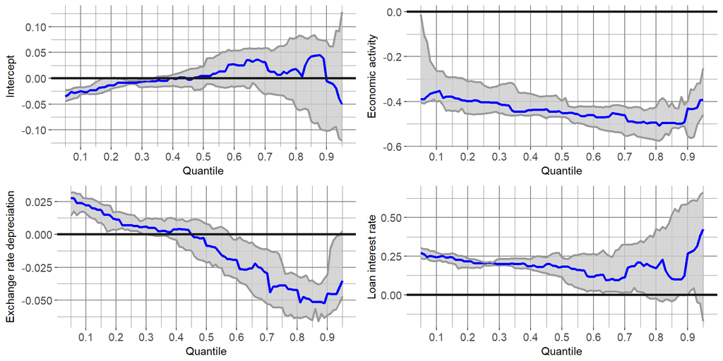

```r
multiplot <- function(..., plotlist=NULL, file, cols=1, layout=NULL) {
  library(grid)

  # Make a list from the ... arguments and plotlist
  plots <- c(list(...), plotlist)

  numPlots = length(plots)

  # If layout is NULL, then use 'cols' to determine layout
  if (is.null(layout)) {
    # Make the panel
    # ncol: Number of columns of plots
    # nrow: Number of rows needed, calculated from # of cols
    layout <- matrix(seq(1, cols * ceiling(numPlots/cols)),
                    ncol = cols, nrow = ceiling(numPlots/cols))
  }

 if (numPlots==1) {
    print(plots[[1]])

  } else {
    # Set up the page
    grid.newpage()
    pushViewport(viewport(layout = grid.layout(nrow(layout), ncol(layout))))

    # Make each plot, in the correct location
    for (i in 1:numPlots) {
      # Get the i,j matrix positions of the regions that contain this subplot
      matchidx <- as.data.frame(which(layout == i, arr.ind = TRUE))

      print(plots[[i]], vp = viewport(layout.pos.row = matchidx$row,
                                      layout.pos.col = matchidx$col))
    }
  }
}

multiplot(gp0, gp2, gp1, gp3, cols = 2)
```

The coefficient for economic activity is quite stable across quantiles, and the lower and upper bounds suggest that they are significantly different from zero. The effect of the exchange rate depreciation changes signs from positive to negative as the quantile increases.

# Confidence Intervals

The `summary()` command could also serves to estimate the confidence intervals using the specificed standard error calculations. The lines below summarize the QR estimations using asymptotic covariance matrices under the assumption of iid and non-iid errors, and via simulations using the bootstrap respectively:

```r
sum_iid  = summary(NPLQR, se="iid")
sum_nid  = summary(NPLQR, se="nid")
sum_boot = summary(NPLQR, se="boot")
```

We can produce the confidence interval tables using an additional library, `knitr`, and its `kable()` command:

```r
if(!require(knitr)){install.packages("knitr")}
library(knitr)

conf_table = function(q_index, st_index, sum_iid, sum_nid, sum_boot, type_stat){
    aux = rbind(coef(sum_iid[[q_index]])[,1], # coefficient
                coef(sum_iid[[q_index]])[,st_index],
                coef(sum_nid[[q_index]])[,st_index],
                coef(sum_boot[[q_index]])[,st_index])
    rownames(aux) = c("coefficient", paste("iid ", type_stat),
                      paste("nid ", type_stat), paste("boot ", type_stat))
    colnames(aux) = c("Intercept","IGAE", "FX", "Rate")
    aux=round(aux,3)
}
idx = which(taus==0.25)
```

for instance, the t-values for the QR for the quantile $\tau=0.25$ are:

```r
type_stat = "t-value, q=0.25"
kable(conf_table(idx, 3, sum_iid, sum_nid, sum_boot, type_stat))
```

[output not shown]

```r
type_stat = "p-value, q=0.25"
kable(conf_table(idx, 4, sum_iid, sum_nid, sum_boot, type_stat))
```

|  | Intercept | IGAE | FX | Rate |
| --- | --- | --- | --- | --- |
| coefficient | -0.008 | -0.404 | 0.007 | 0.203 |
| iid p-value, q=0.25 | 0.164 | 0.000 | 0.049 | 0.000 |
| nid p-value, q=0.25 | 0.146 | 0.000 | 0.061 | 0.000 |
| boot p-value, q=0.25 | 0.167 | 0.000 | 0.112 | 0.000 |

# Hypothesis testing

## Equality of slopes across quantiles

To test whether slopes are the same across quantiles, we need to estimate separate models for each desired quantile:

```r
fit10 = rq(formula, data=completeData,tau=0.10)
fit25 = rq(formula, data=completeData,tau=0.25)
fit50 = rq(formula, data=completeData,tau=0.50)
fit75 = rq(formula, data=completeData,tau=0.75)
fit90 = rq(formula, data=completeData,tau=0.90)
```

The `anova` command allows us to test if the slopes are equal or not. The option `joint="FALSE"` serves to test individual slopes. Specifying `joint="TRUE"` will test whether the slopes of all the covariates are the same.

```r
anova(fit10, fit25, joint="FALSE")
```

```
## Quantile Regression Analysis of Deviance Table
##
## Model: logNPLCons ~ IGAEgrowth + FXdepr + RateConsumer
## Tests of Equality of Distinct Slopes: tau in {  0.1 0.25  }
##
##              Df Resid Df F value   Pr(>F)
## IGAEgrowth    1      311  5.3939 0.020853 *
## FXdepr        1      311 10.5063 0.001319 **
## RateConsumer  1      311  2.2175 0.137471
## ---
## Signif. codes:  0 '***' 0.001 '**' 0.01 '*' 0.05 '.' 0.1 ' ' 1
```

```r
anova(fit25, fit50, joint="FALSE")
```

```
## Quantile Regression Analysis of Deviance Table
##
## Model: logNPLCons ~ IGAEgrowth + FXdepr + RateConsumer
## Tests of Equality of Distinct Slopes: tau in {  0.25 0.5  }
##
##              Df Resid Df F value  Pr(>F)
## IGAEgrowth    1      311  4.5686 0.03334 *
## FXdepr        1      311  6.1539 0.01364 *
## RateConsumer  1      311  0.3226 0.57045
## ---
## Signif. codes:  0 '***' 0.001 '**' 0.01 '*' 0.05 '.' 0.1 ' ' 1
```

```r
anova(fit50, fit75, joint="FALSE")
```

```
## Quantile Regression Analysis of Deviance Table
##
## Model: logNPLCons ~ IGAEgrowth + FXdepr + RateConsumer
## Tests of Equality of Distinct Slopes: tau in {  0.5 0.75  }
##
##              Df Resid Df F value    Pr(>F)
## IGAEgrowth    1      311  1.8154 0.1788443
## FXdepr        1      311 11.5225 0.0007767 ***
## RateConsumer  1      311  0.2670 0.6056907
## ---
## Signif. codes:  0 '***' 0.001 '**' 0.01 '*' 0.05 '.' 0.1 ' ' 1
```

```r
anova(fit75, fit90, joint="FALSE")
```

```
## Quantile Regression Analysis of Deviance Table
##
## Model: logNPLCons ~ IGAEgrowth + FXdepr + RateConsumer
## Tests of Equality of Distinct Slopes: tau in {  0.75 0.9  }
##
##              Df Resid Df F value Pr(>F)
## IGAEgrowth    1      311  1.6174 0.2044
## FXdepr        1      311  0.3366 0.5622
## RateConsumer  1      311  0.4839 0.4872
```

## Nested models

We can also tests whether more restricted models are valid or not. First, specify the different models:

```r
formula1 = logNPLCons ~ IGAEgrowth
formula2 = logNPLCons ~ IGAEgrowth + FXdepr
formula3 = logNPLCons ~ IGAEgrowth + FXdepr + RateConsumer
formula4 = logNPLCons ~ IGAEgrowth + RateConsumer
```

```r
fit1 = rq(formula1, data=completeData, tau =0.50)
fit2 = rq(formula2, data=completeData, tau =0.50)
fit3 = rq(formula3, data=completeData, tau =0.50)
fit4 = rq(formula4, data=completeData, tau =0.50)
```

The `anova` command is used again to test the null hypothesis that rejects the more restricted model:

```r
anova(fit1, fit2)
```

```
## Quantile Regression Analysis of Deviance Table
##
## Model 1: logNPLCons ~ IGAEgrowth + FXdepr
## Model 2: logNPLCons ~ IGAEgrowth
##   Df Resid Df F value Pr(>F)
## 1  1      153  0.0889  0.766
```

```r
anova(fit2, fit3)
```

```
## Quantile Regression Analysis of Deviance Table
##
## Model 1: logNPLCons ~ IGAEgrowth + FXdepr + RateConsumer
## Model 2: logNPLCons ~ IGAEgrowth + FXdepr
##   Df Resid Df F value    Pr(>F)
## 1  1      152  16.733 6.957e-05 ***
## ---
## Signif. codes:  0 '***' 0.001 '**' 0.01 '*' 0.05 '.' 0.1 ' ' 1
```

```r
anova(fit3, fit4)
```

```
## Quantile Regression Analysis of Deviance Table
##
## Model 1: logNPLCons ~ IGAEgrowth + FXdepr + RateConsumer
## Model 2: logNPLCons ~ IGAEgrowth + RateConsumer
##   Df Resid Df F value Pr(>F)
## 1  1      152   1.274 0.2608
```

# Scale shifts

Scale shifts required calculating the differences between the fitted values at different quantile levels equidistant from the median, i.e. 10 percent and 90 percent, 75 percent and 25 percent:

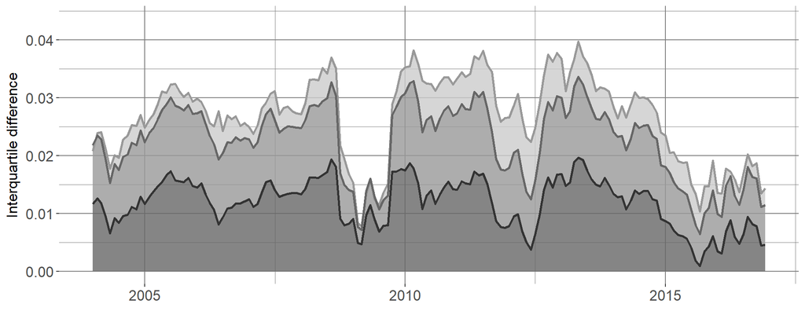

```r
dif9505 = NPLQR$fitted.values[,7] - NPLQR$fitted.values[,1]
dif9010 = NPLQR$fitted.values[,6] - NPLQR$fitted.values[,2]
dif7525 = NPLQR$fitted.values[,5] - NPLQR$fitted.values[,3]
fig.df = data.frame(completeData$Date, dif9505, dif9010, dif7525)
colnames(fig.df)[1] = "Date"
ggplot(fig.df, aes(x=Date)) +
    geom_ribbon(aes(ymin = dif9010, ymax = dif9505), fill="gray80", alpha =0.8) +
    geom_ribbon(aes(ymin = dif7525, ymax = dif9010), fill="gray60", alpha =0.8) +
    geom_ribbon(aes(ymin = 0*dif9010, ymax = dif7525), fill="gray40", alpha =0.8) +
    geom_line(aes(y=dif9505), color="gray60", size=1) +
    geom_line(aes(y=dif9010), color="gray40", size=1) +
    geom_line(aes(y=dif7525), color="gray20", size=1) +
    ylim(0, max(dif9505)*1.1 ) +
    xlab("") + ylab("Interquartile difference") +
    theme(plot.background = element_rect(fill="transparent", colour=NA),
        #panel.grid.major = element_blank(),
        #panel.grid.minor = element_blank()
        panel.grid.major = element_line(colour="gray50"),
        panel.grid.minor = element_line(colour="gray50"),
        #panel.border = element_rect(linetype = "solid", colour="gray50", fill = NA),
        panel.border = element_blank(),
        panel.background = element_blank(),
        axis.text = element_text(size=rel(1.2)),
        axis.title.y = element_text(size= rel(1.2))
        )
```

# Skewness shifts

To measure shifts in the skewness of the distribution, for a given quantile $p$, with $p>0.50$ we calculate the difference between the fitted values of the response variable using the QR($p$) and QR(0.50) models, and divide it by the difference between the fitted values of the QR(50) and QR(1-$p$) models. This is illustrated below for $p=75$:

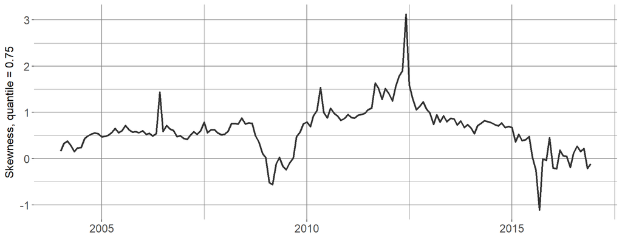

```r
dif7550 = NPLQR$fitted.values[,5] - NPLQR$fitted.values[,4]
dif5025 = NPLQR$fitted.values[,4] - NPLQR$fitted.values[,3]
skew75 = dif7550/dif5025 -1

fig.df = data.frame(completeData$Date, skew75)
ggplot(fig.df, aes(x=Date)) +
    geom_line(aes(y=skew75), color="gray20", size=1) +
    xlab("") + ylab("Skewness, quantile = 0.75") +
    theme(plot.background = element_rect(fill="transparent", colour=NA),
        panel.grid.major = element_line(colour="gray50"),
        panel.grid.minor = element_line(colour="gray50"),
        panel.border = element_blank(),
        panel.background = element_blank(),
        axis.text = element_text(size=rel(1.2)),
        axis.title.y = element_text(size= rel(1.2))
        )
```

# Goodness of fit

For a linear QR model, Koenker and Machado (2005) propose using a measure equal to one minus the ratio of the deviance of the fitted model to the deviance of a model that only includes the intercept. The deviance of the model is simply the value of the objective function minimized when estimating the QR. After estimating the model, it can be obtained from the QR object by retrieiving the `rho` parameter from its structure.

```r
taus = c(0.05, 0.10, 0.25, 0.50, 0.75, 0.90, 0.95)
formula_fixed = logNPLCons ~ 1
NPLQRfixed = rq(formula_fixed, data = completeData, tau=taus)
V_fixed = NPLQRfixed$rho
V_NPLQR = NPLQR$rho
R_tau = 1 - V_NPLQR/V_fixed
names(R_tau) = c("q=0.05", "q=0.10","q=0.25","q=0.50","q=0.75","q=0.90","q=0.95")
round(R_tau,3)
```

```
## q=0.05 q=0.10 q=0.25 q=0.50 q=0.75 q=0.90 q=0.95
##  0.370  0.407  0.394  0.343  0.414  0.522  0.535
```